# Data Science Capstone in R - Week 2 Analysis Alternate Version

Ken Wood

10/7/2020

### Instructions

1. Demonstrate that we’ve downloaded the data and have successfully loaded it in.
2. Create a basic report of summary statistics about the data sets.
3. Report any interesting findings that we have amassed so far.
4. Get feedback on our plans for creating a prediction algorithm and Shiny app.

### Considerations for the Analysis

1. **Loading the data in.** This dataset is fairly large. We don’t necessarily need to load the entire dataset in to build our algorithms (see point 2 below). At least initially, we might want to use a smaller subset of the data. Reading in chunks or lines using R’s readLines or scan functions can be useful.
2. **Sampling.** To build our models we don’t need to load in and use all of the data. Often relatively few randomly selected rows or chunks need to be included to get an accurate approximation to results that would be obtained using all the data. We might want to create a separate sub-sample dataset by reading in a random subset of the original data and writing it out to a separate file. That way, we can store the sample and not have to recreate it every time. We can use the rbinom function to “flip a biased coin” to determine whether we sample a line of text or not.

### Review Criteria

1. Does the link lead to an HTML page describing the exploratory analysis of the training data set?
2. Has the data scientist done basic summaries of the three files? Word counts, line counts and basic data tables?
3. Has the data scientist made basic plots, such as histograms to illustrate features of the data?
4. Was the report written in a brief, concise style, in a way that a non-data scientist manager could appreciate?

### Load the necessary R packages…

```r
library(R.utils)     # various R programming facilities
library(ggplot2)     # ggplot plotting package
library(ngram)       # R package for constructing n-grams (“tokenizing”), as well as                           generating new text based on the n-gram structure of a given                             text input (“babbling”)
library(dplyr)       # data manipulation utilities
library(slam)        # sparse lightweight arrays and matrices
library(tidytext)    # tidy text mining package
library(textmineR)   # functions for text mining and topic modeling
library(tau)         # text analysis utilities
library(stringi)     # character string processing package
library(tm)          # text mining package
library(RWeka)       # a collection of machine learning algorithms for data mining tasks written in Java
library(SnowballC)   # a R interface to the C 'libstemmer' library that implements Porter's word stemming algorithm for collapsing words to a common root to aid comparison of vocabulary.
```

```r
blogs <- "final/en_US/en_US.blogs.txt"
news <- "final/en_US/en_US.news.txt"
twitter <- "final/en_US/en_US.twitter.txt"
```

### Analysis for `en_US.blogs.txt`

```r
blog_line <- readLines(blogs,encoding="UTF-8", skipNul = TRUE)
num_blog_lines <- sapply(blogs,countLines)  # count number of lines in file
num_blog_words <- wordcount(blog_line, sep = " ", count.function = sum) # count number of words in file
print(paste("Number of lines - blogs: ",num_blog_lines))
```

```
## [1] "Number of lines - blogs:  899288"
```

```r
print(paste("Number of words - blogs: ",num_blog_words))
```

```
## [1] "Number of words - blogs:  37334131"
```

### Analysis for `en_US.news.txt`

```r
news_line <- readLines(news,encoding="UTF-8", skipNul = TRUE)
num_news_lines <- sapply(news,countLines)   # count number of lines in file
num_news_words <- wordcount(news_line, sep = " ", count.function = sum)  # count number of words in file
print(paste("Number of lines - news: ",num_news_lines))
```

```
## [1] "Number of lines - news:  1010242"
```

```r
print(paste("Number of words - news: ",num_news_words))
```

```
## [1] "Number of words - news:  34372530"
```

### Analysis for `en_US.twitter.txt`

```r
twitter_line <- readLines(twitter,encoding="UTF-8", skipNul = TRUE)
num_twitter_lines <- sapply(twitter,countLines)  # count number of lines in file
num_twitter_words <- wordcount(twitter_line, sep = " ", count.function = sum)  # count number of words in file
print(paste("Number of lines - twitter: ",num_twitter_lines))
```

```
## [1] "Number of lines - twitter:  2360148"
```

```r
print(paste("Number of words - twitter: ",num_twitter_words))
```

```
## [1] "Number of words - twitter:  30373583"
```

### Create a sample dataset using 5% each of the `.txt` files

```r
set.seed(42)

data.sample <- c(blog_line[sample(1:length(blog_line),length(blog_line)*0.05)],
                 news_line[sample(1:length(news_line),length(news_line)*0.05)],
                 twitter_line[sample(1:length(twitter_line),length(twitter_line)*0.05)] )
```

#### Remove `blog_line`,`news_line` and `twitter_line` files to free up memory since we don’t need them anymore.

```r
rm(list=c("blog_line","news_line","twitter_line"))
```

### Clean the corpus using functions in the `tm` package…

```r
sample_corpus = VCorpus(VectorSource(data.sample))
sample_corpus = tm_map(sample_corpus, content_transformer(tolower))
sample_corpus = tm_map(sample_corpus, removeNumbers)
sample_corpus = tm_map(sample_corpus, removePunctuation)
sample_corpus = tm_map(sample_corpus, removeWords, stopwords())
sample_corpus = tm_map(sample_corpus, stemDocument)
sample_corpus = tm_map(sample_corpus, stripWhitespace)
```

### Define a function that computes n-grams in a sample corpus and plots the frequency of occurrence.

```r
n_grams_plot <- function(n, data) {
  options(mc.cores=1)

  # Build a  n-gram tokenizer
  token <- function(x) NGramTokenizer(x, Weka_control(min = n, max = n))

  # Create a matrix of n-grams
  ngrams_matrix <- TermDocumentMatrix(data, control=list(tokenize=token))

  # Transform the matrix for easy visualization
  ngrams_matrix <- as.matrix(rollup(ngrams_matrix, 2, na.rm=TRUE, FUN=sum))
  ngrams_matrix <- data.frame(word=rownames(ngrams_matrix), freq=ngrams_matrix[,1])

  # Find the 10 most frequent n-grams in the matrix
  ngrams_matrix <- ngrams_matrix[order(-ngrams_matrix$freq), ][1:15, ]
  ngrams_matrix$word <- factor(ngrams_matrix$word, as.character(ngrams_matrix$word))

  # plots
  ggplot(ngrams_matrix, aes(x=word, y=freq)) +
    geom_bar(stat="Identity") +
    theme(axis.text.x = element_text(angle = 90, hjust = 1)) + xlab(paste(n,"- grams")) +
    ylab("Frequency") + ggtitle(paste(n,"- gram Frequencies")) +
                                  theme(plot.title = element_text(hjust = 0.5))
}
```

Let’s plot of frequency distribution of 1-grams

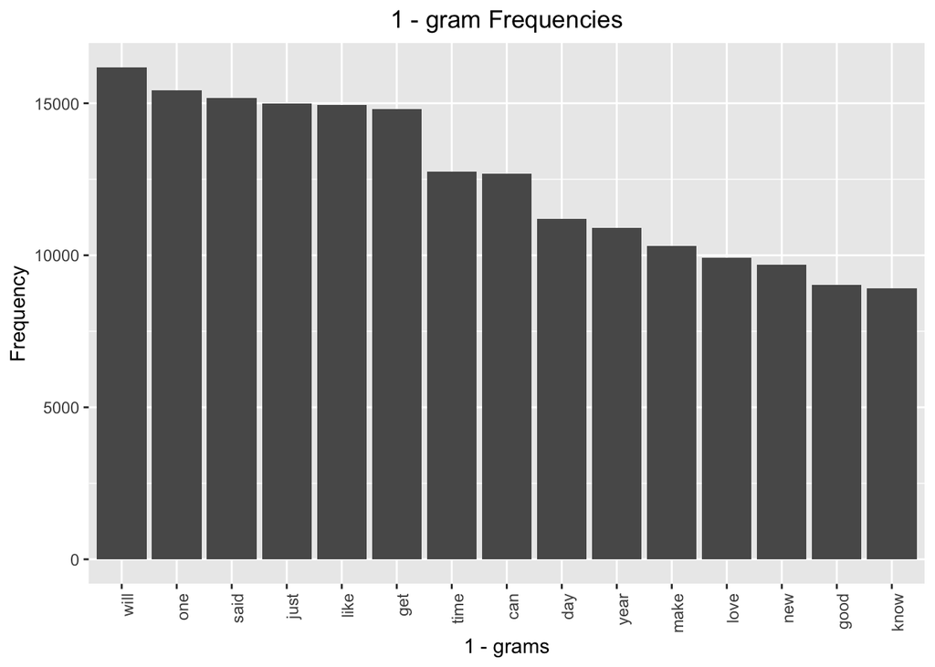

```r
n_grams_plot(n=1, data=sample_corpus)
```

Let’s plot of frequency distribution of 2-grams

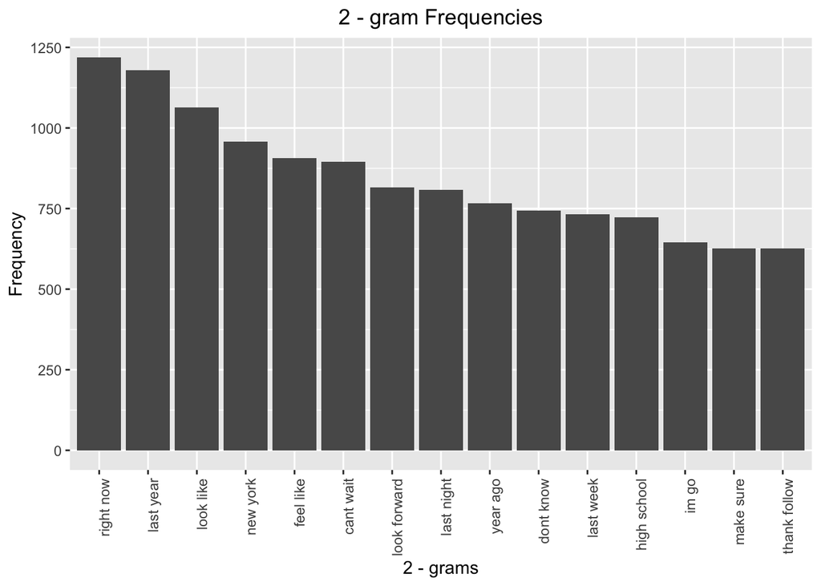

```r
n_grams_plot(n=2, data=sample_corpus)
```

Let’s plot of frequency distribution of 3-grams

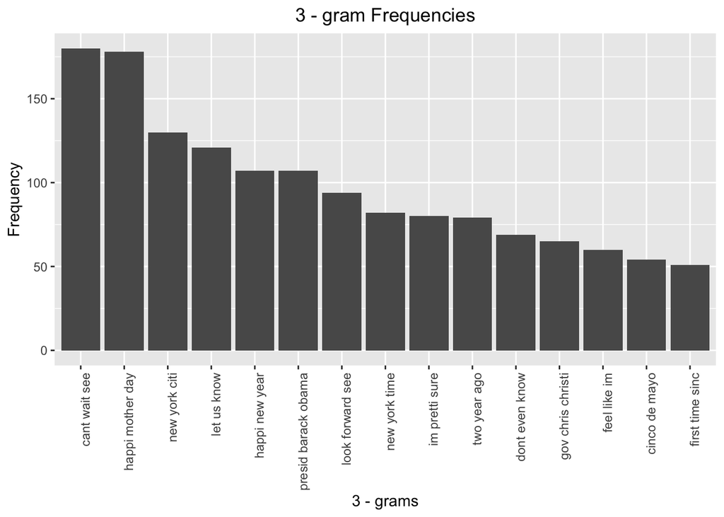

```r
n_grams_plot(n=3, data=sample_corpus)
```